# A rising tide lifts all podcasts

Alex Albright

7-26-17

# Motivation

Lucy McGowan looked into the growth of ‘Drunk’ Podcasts in her recent [blog post.](http://livefreeordichotomize.com/2017/02/09/the-prevalence-of-drunk-podcasts/) She found a huge growth in that “genre” (if you will). Moreover, she expresses that:

> While it is certainly true that the number of podcasts in general has absolutely increased over this time period, I would be surprised if the increase is as dramatic as the increase in the number of “drunk” podcasts.

I was skeptical about this claim and wanted to look into trends in other general categories. Also, I wanted an excuse to use emojis in plots. :)

# Code time!

Load libraries:

```r
library(dplyr);library(ggplot2);library(ggrepel); library(extrafont); library(ggthemes);library(reshape);library(grid);
library(scales);library(RColorBrewer);library(gridExtra); library(emoGG)
```

Define my plot theme (for graphics that will come later) as usual:

```r
#Define theme for my visuals
my_theme <- function() {
  # Define colors for the chart
  palette <- brewer.pal("Greys", n=9)
  color.background = palette[2]
  color.grid.major = palette[4]
  color.panel = palette[3]
  color.axis.text = palette[9]
  color.axis.title = palette[9]
  color.title = palette[9]
  # Create basic construction of chart
  theme_bw(base_size=9, base_family="Palatino") +
  # Set the entire chart region to a light gray color
  theme(panel.background=element_rect(fill=color.panel, color=color.background)) +
  theme(plot.background=element_rect(fill=color.background, color=color.background)) +
  theme(panel.border=element_rect(color=color.background)) +
  # Format grid
  theme(panel.grid.major=element_line(color=color.grid.major,size=.25)) +
  theme(panel.grid.minor=element_blank()) +
  theme(axis.ticks=element_blank()) +
  # Format legend
  theme(legend.position="right") +
  theme(legend.background = element_rect(fill=color.background)) +
  theme(legend.text = element_text(size=7,color=color.axis.title)) +
  theme(legend.title = element_text(size=0,face="bold", color=color.axis.title)) +

  #Format facet labels
  theme(strip.text.x = element_text(size = 8, face="bold"))+
  # Format title and axes labels these and tick marks
  theme(plot.title=element_text(color=color.title, size=18, face="bold")) +
  theme(axis.text.x=element_text(size=6,color=color.axis.text)) +
  theme(axis.text.y=element_text(size=6,color=color.axis.text)) +
  theme(axis.title.x=element_text(size=0,color=color.axis.title, vjust=-1, face="bold")) +
  theme(axis.title.y=element_text(size=0,color=color.axis.title, vjust=1.8, face="bold")) +
  #Format title and facet_wrap title
  theme(strip.text = element_text(size=8), plot.title = element_text(size = 10, face = "bold", colour = "black", vjust = 1, hjust=0.5))+

  # Plot margins
  theme(plot.margin = unit(c(.2, .2, .2, .2), "cm"))
}
```

Many of the next chunks are directly adapted straight from Lucy’s shared code–thanks Lucy! I search for different terms and finesse my plots differently but Lucy should be given credit for the base code.

For plots, I scrolled through emojis and procured their unicode codes [here](https://apps.timwhitlock.info/emoji/tables/unicode). I could have also used `emoji_search` in the `emoGG` package if I knew the names of the emojis I wanted.

### ‘Comedy’ Podcasts

Pull data:

```r
req <- httr::GET(url = "https://itunes.apple.com/search",
          query = list(
            term = "comedy",
            media = "podcast",
            limit = 200
          ))
itunes <- jsonlite::fromJSON(httr::content(req))$results
```

Plot:

```r
comedy<-itunes %>%
  mutate(date = as.Date(releaseDate),monyear = zoo::as.yearmon(date)) %>%
  group_by(monyear) %>%
  summarise(n = n()) %>%
  mutate(date = zoo::as.Date(monyear)) %>%
  ggplot(aes(x = date,y=n)) +
    scale_x_date(date_breaks = "1 year", date_labels = "%Y") +
    scale_y_continuous(limits=c(0, 150), breaks=seq(0,150,25))+
    emoGG::geom_emoji(emoji="1f602") +
    labs(title="'Comedy' podcast releases") +
    my_theme()
```

### ‘Politics’ Podcasts

Pull data:

```r
req <- httr::GET(url = "https://itunes.apple.com/search",
          query = list(
            term = "politics",
            media = "podcast",
            limit = 200
          ))
itunes <- jsonlite::fromJSON(httr::content(req))$results
```

Plot:

```r
politics<-itunes %>%
  mutate(date = as.Date(releaseDate),monyear = zoo::as.yearmon(date)) %>%
  group_by(monyear) %>%
  summarise(n = n()) %>%
  mutate(date = zoo::as.Date(monyear)) %>%
  ggplot(aes(x = date,y=n)) +
    scale_x_date(date_breaks = "1 year", date_labels = "%Y") +
    scale_y_continuous(limits=c(0, 150), breaks=seq(0,150,25))+
    emoGG::geom_emoji(emoji="270a") +
    labs( title="'Politics' podcast releases") +
    my_theme()
```

### ‘Sports’ Podcasts

Pull data:

```r
req <- httr::GET(url = "https://itunes.apple.com/search",
          query = list(
            term = "sports",
            media = "podcast",
            limit = 200
          ))
itunes <- jsonlite::fromJSON(httr::content(req))$results
```

Plot:

```r
sports<-itunes %>%
  mutate(date = as.Date(releaseDate),monyear = zoo::as.yearmon(date)) %>%
  group_by(monyear) %>%
  summarise(n = n()) %>%
  mutate(date = zoo::as.Date(monyear)) %>%
  ggplot(aes(x = date,y=n)) +
    scale_x_date(date_breaks = "1 year", date_labels = "%Y") +
    emoGG::geom_emoji(emoji="26bd") +
    scale_y_continuous(limits=c(0, 150), breaks=seq(0,150,25))+
    labs(title="'Sports' podcast releases") +
    my_theme()
```

### ‘Science’ Podcasts

Pull data:

```r
req <- httr::GET(url = "https://itunes.apple.com/search",
          query = list(
            term = "science",
            media = "podcast",
            limit = 200
          ))
itunes <- jsonlite::fromJSON(httr::content(req))$results
```

Plot:

```r
science<-itunes %>%
  mutate(date = as.Date(releaseDate),monyear = zoo::as.yearmon(date)) %>%
  group_by(monyear) %>%
  summarise(n = n()) %>%
  mutate(date = zoo::as.Date(monyear)) %>%
  ggplot(aes(x = date,y=n)) +
    scale_x_date(date_breaks = "1 year", date_labels = "%Y") +
    scale_y_continuous(limits=c(0, 150), breaks=seq(0,150,25))+
    emoGG::geom_emoji(emoji="1f52c") +
    labs(title="'Science' podcast releases") +
    my_theme()
```

# The final product!

**Now, I can combine all four plots into one aggregated piece of evidence that, wow, yeah, lots of podcasts have seen dramatic increases in 2017!**

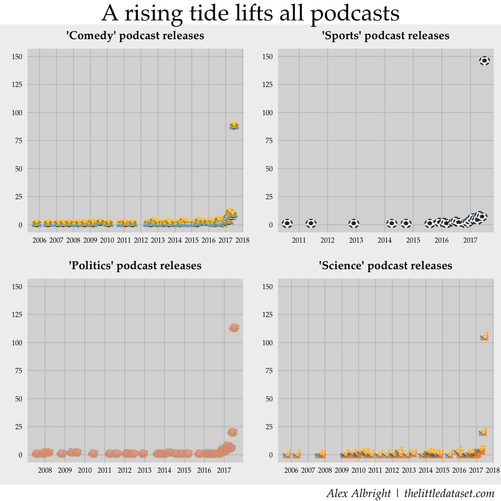

```r
grid.arrange(comedy, sports, politics, science, ncol=2, nrow=2, top=textGrob("A rising tide lifts all podcasts", gp=gpar(fontsize=20, fontfamily="Palatino")), bottom=textGrob("Alex Albright | thelittledataset.com", hjust=-.45, gp=gpar(fontsize=10, font=3, fontfamily="Palatino")))
```

Yay for `geom_emoji` in the `emoGG` package! Does anyone know how to alter the skin tone for the “fist” emoji? While I know the emoji itself [supports skin tone modifiers](https://emojipedia.org/raised-fist-type-4/), I could not figure out how to incorporate modifiers in the context of `geom_emoji`.

Now, let’s save this as a pdf.

```r
#save to pdf
pdf("pods.pdf", width = 7, height = 7) # Open a new pdf file
grid.arrange(comedy, sports, politics, science, ncol=2, nrow=2, top=textGrob("A rising tide lifts all podcasts", gp=gpar(fontsize=20, fontfamily="Palatino")), bottom=textGrob("Alex Albright | thelittledataset.com", hjust=-.45, gp=gpar(fontsize=10, font=3, fontfamily="Palatino"))) # Write the grid.arrange to a pdf file
dev.off()
```

# [The end!](https://i.redd.it/2302x89w2e8y.jpg)